# SRLM Function Documentation and Testing

This function calculates the right-hand side of the system of ODEs that make up the SRLM (i.e., for use in the ode45 function that runs the SRLM). It is a function of p (the occupancy proportions) over N patches (n.patches), the colonization (c.rate) and extinction rates (E), the dispersal function evaluations f.vals (i.e., f(dij;i,j)), the areas of the patches (A), configuration of patches on and off (where the patches that are turned off and do not contribute to the rhs of the ODE system), and whether patches have self recruitment (binary, self.rec, 0 = no self recruitment, 1 = self recruitment).

**NOTE:** R’s ode solver sadly has not been well equipped to handle parameters provided by vectors or matrices. i.e. You can’t have a parameter that’s a vector or a matrix and just pass it through to be used in the calculation. Rather, R requires each single parameter to be used be named and provided in a list. This makes passing vectors and matrices of arbitrarily large sizes A NIGHTMARE (I have literally not found a single example of someone else doing this online)! But that’s what I have done here and it works.

**For reference though, this is how the list of parameters is structured:**

1. **n.patches**, N, the number of patches (on or off) in the landscape
2. **c.rate**, c, the rate of patch colonization
3. **self.rec**, whether or not self recruitment occurs

4:3+N) **E**, e, the within patch rates of extinction, vector populates a 1D matrix **EXRATE**

4+N:3+2N) **x.coord**, the x coordinates of patches, vector not used in this calculation

4+2N:3+3N) **y.coord**, the y coordinates of patches, vector not used in this calculation

4+3N:3+4N) **A**, the areas of each patch, vector populates a 1D matrix **AREAS**

4+4N:3+5N) **Config**, the configuration of patches on and off in binary (1=on, 0=off), vector populates a 1D matrix **CONFIG**

4+5N:3+5N+N^2) **f.vals**, the dispersal function evaluations (f(dij;i,j)), matrix populates a NxN matrix **DISPKERNEL**

Basically all this annoying code biols down to: **dP=c(AREAS)(DISPKERNAL)-EXRATE(P)** for all the patches that are on and excluding the ability for a patch to colonize itself unless self recruitment is enabled

```r
SRLM.ODE<-function(t,p,parameters){
  with(c(p, parameters), {
    ###############################################################################################
    #parameters index just for reference
    ###############################
    #n.patches<-parameters[1]
    #c.rate<-parameters[2]
    #self.rec<-parameters[3]
    #E<-parameters[4:(3+n.patches)]
    #x.coord<-parameters[(4+n.patches):(3+n.patches*2)]
    #y.coord<-parameters[(4+n.patches*2):(3+n.patches*3)]
    #A<-parameters[(4+n.patches*3):(3+n.patches*4)]
    #config<-parameters[(4+n.patches*4):(3+n.patches*5)]
    #f.vals<-parameters[(4+n.patches*5):(3+n.patches*5+(n.patches*n.patches))]
    ###############################################################################################
    #Set up 1D and 2D matrices of parameters for input into the ODEs
    ###############################################################################################
    P=matrix(p, n.patches, 1)
    AREA=matrix(parameters[[1]][(4+n.patches*3):(3+n.patches*4)], n.patches, 1)
    CONFIG=matrix(parameters[[1]][(4+n.patches*4):(3+n.patches*5)], n.patches, 1)
    EXRATE=matrix(parameters[[1]][4:(3+n.patches)], n.patches, 1)
    DISPKERNEL=matrix(parameters[[1]][(4+n.patches*5):(3+n.patches*5+(n.patches*n.patches))], n.patches, n.patches)
    ###############################################################################################
    #create a 1D matrix to hold the right hand side of the ODE equations (dp)
    dP=matrix(rep(NA, n.patches), n.patches, 1)
    interactions<-0 #we don't have any interactions in this model at the moment so ignore this term
    ###############################################################################################
    #Loops to construct the system of ODEs
    for (i in 1:n.patches){ #for each patch
      for (j in 1:n.patches){ #to each other patch (including itself)
        if (i!=j & CONFIG[i,1]!=0){ #if it's not itself and it's not off
          dP[i,1]<-interactions + c.rate*AREA[j,1]*DISPKERNEL[i,j]*P[j,1]*(1-P[i,1])} #then the pop dynamics occur
        if (i==j & CONFIG[i,1]!=0){ #if the patch is itself and it's not off
          if (self.rec==1){ #if self recruitment is on
            dP[i,1]<-interactions + c.rate*AREA[j,1]*DISPKERNEL[i,j]*P[j,1]*(1-P[i,1])} #pop dynamics occur
        }
        else if ((i==j & self.rec==0) | CONFIG[i,]==0){ #otherwise, if self recruitment is off
          #or the patch is just off
          dP[i,1]<-0}#pop dynamics don't occur and the equation is just = 0
        interactions<-dP[i,1]
      }

      if (CONFIG[i,]!=0){
        dP[i,1]<-dP[i,1] - EXRATE[i,1]*P[i,1]}
    }
    ###############################################################################################
    dP.names<-c(rep(paste0("dP",1:n.patches)))
    dP.values<-dP
    RHS<-list(c(setNames(dP.values, dP.names)))
    return(RHS)
  }) # end with(as.list ...
}
```

I checked this output against Austin’s Matlab output and they match. <- Except that this is wrong because e(Pi) was being repeatedly subtracted. My function is now correct.

Loading necessary packages and functions:

```r
library("pracma")
library("deSolve")
setwd("C:/Users/abuga/OneDrive/Desktop/HVMcode")
```

```
The working directory was changed to C:/Users/abuga/OneDrive/Desktop/HVMcode inside a notebook chunk. The working directory will be reset when the chunk is finished running. Use the knitr root.dir option in the setup chunk to change the working directory for notebook chunks.
```

```r
source("create_landscape_func.r")
```

[output not shown]

Setting our parameters:

```r
total.t<-5000 #total time to run the model (optional; could run to absorption)
landscape<-create.landscape(n.patches=4, landscape.type="2D", landscape.limit=20,
                patch.distribution="clustered", areas.distribution="random", areas.limit=2,
                clustering.iters=10)
n.patches<-length(landscape$patch.ID)
alpha<-0.3
e.rate<-0.01
c.rate<-4
self.rec<-1
gamma<-0
epsilon<-n.patches
delta<-e.rate/c.rate
#rates of vents turning off to on and on to off respectively
r1<-1/100000#0.02
r2<-1/100#0.01
config<-rbinom(n.patches, 1, 0.5)
while(sum(config)==0){#just to ensure we don't start in the absorbing state
  config<-rbinom(n.patches, 1, 0.5)
}
```

Calculations to use these to obtain all our parameters for the SRLM ODE

```r
x.coord<-landscape$x.coord
y.coord<-landscape$y.coord
areas<-landscape$areas
#calculate E for each patch
extinction.rates<-e.rate/areas
# construct the distance matrix
dist.mat<-matrix(rep(0,n.patches*n.patches),n.patches,n.patches)
for (i in 1:n.patches){
  for (j in 1:n.patches){
    dist.mat[i,j]<-sqrt((x.coord[i]-x.coord[j])^2+(y.coord[i]-y.coord[j])^2)
  }
}
#Getting the f(dij) values to plug into the rhs
f.vals<-disp.kernel(dist.mat,alpha,gamma,epsilon,self.rec,n.patches)
f.vals<-as.vector(f.vals)
f.names<-matrix(rep(NA,n.patches*n.patches),n.patches,n.patches)
for (i in 1:n.patches){
  for (j in 1:n.patches){
    f.names[i,j]<-paste0("f.vals",i,j)
  }
}
f.names<-as.vector(f.names)
```

creating a named list of the parameters we calculated to be passed to our ODE function

```r
names<-c("n.patches", "c.rate", "self.rec",
         rep(paste0("extinction.rates",1:n.patches)),
         rep(paste0("x.coord",1:n.patches)),
         rep(paste0("y.coord",1:n.patches)),
         rep(paste0("areas",1:n.patches)),
         rep(paste0("config",1:n.patches))
         ,f.names
         )
values<-c(n.patches,c.rate,self.rec,extinction.rates,x.coord,y.coord,areas,config
          ,f.vals
          )
parameters<-list(c(setNames(values, names)))
```

setting our intial values

```r
new.ICs<-0.5*config
IC.names<-rep(paste0("p",1:n.patches))
IC.values<-new.ICs
p<-setNames(IC.values,IC.names)
tau<-4000 #just for checking
```

To ensure the metapopulation actually is able to persist in the landscape and we don’t just get a flat line of extinction for our simulation, let’s scale our e.rate and c.rate to ensure a high enough persistence capacity the metapopulation has the opportunity to experience some growth

```r
lambda.M<-get.lambda.M(landscape, alpha, gamma, epsilon, self.rec, e.rate, c.rate)
lambda.M
```

```
[1] 2.594299
```

```r
e.rate/c.rate
```

```
[1] 0.0025
```

I checked this against Austin’s matlab code and they match

Now finally solving our set of ODE’s for time increments of 1 from t=0 to t=tau (when a configuration change would occur if this was being run with the habitat CTMC)

```r
output<-ode(SRLM.ODE, parameters,times=seq(0,round(tau,0),1),y=p)
head(output)
```

```
     time p1 p2        p3 p4
[1,]    0  0  0 0.5000000  0
[2,]    1  0  0 0.9980283  0
[3,]    2  0  0 0.9991353  0
[4,]    3  0  0 0.9991367  0
[5,]    4  0  0 0.9991367  0
[6,]    5  0  0 0.9991367  0
```

Again I checked this against Austin’s matlab code and they match

```r
out <- ode(SRLM.ODE, y=p, parms=parameters, times =seq(0,5000,1), rootfun = at.equilibrium)
head(out)
```

```
         time p1 p2        p3 p4
[1,] 0.000000  0  0 0.5000000  0
[2,] 1.000000  0  0 0.9980283  0
[3,] 1.633434  0  0 0.9991219  0
```

```r
tail(out, n = 2) #look at the end of the simulation
```

```
         time p1 p2        p3 p4
[2,] 1.000000  0  0 0.9980283  0
[3,] 1.633434  0  0 0.9991219  0
```

```r
x<-out[length(out[,1]),-1]-out[length(out[,1])-1,-1] #calculate the final change in patch occupancy
Norm(x) #check that the norm is below 1e-4
```

```
[1] 0.001093611
```

plotting the SRLM dynamics over time to check

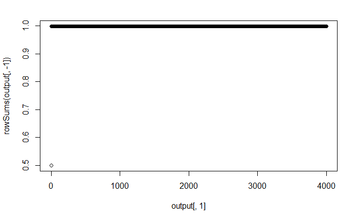

```r
plot(output[,1], rowSums(output[,-1]))
```